# skimmingLoci Tutorial

Marcelo Reginato

skimmingLoci: a pipeline to assemble low copy nuclear markers from genome skimming data

## Example data set

In this tutorial we are going to use an example data set including a reference set of low copy nuclear markers (20 markers in fasta format - reference.fasta) and paired-read genome skimming libraries (filtered reads) from 16 species (*.fastq.gz).

This data set can be downloaded [here](https://github.com/mreginato/skimmingLoci/raw/main/Example_data_set.zip). After extracting the zip file, the folder should have these files:

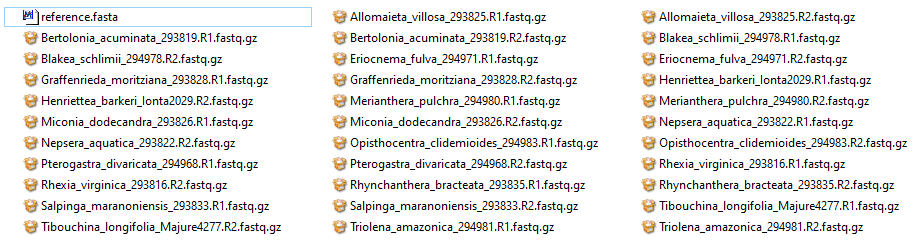

*When running the pipeline with other data set it is mandatory that the files should be named **exactly** as in the example data set.*

- Reference (fasta format) → something.fasta
- Libraries (fastq.gz format) → My_library_name.R1.fastq.gz & My_library_name.R2.fastq.gz My_other_library_name.R1.fastq.gz & My_other_library_name.R2.fastq.gz

## Running

The pipeline can be executed step by step or with all steps at once. In this first example we’ll run it step by step.

### Step by step

The pipeline has 4 basic steps that should be executed in the following order:

- Mapping (-m)
- SNPs calling (-s)
- Consensus generation (-c)
- Alignment (-a)

#### 1. Mapping (-m)

This step uses the reference (.fasta) and fastq.gz files, paired (.R1.fastq.gz, .R2.fastq.gz) or single (.R1.fastq.gz) and generates *.bam files in a folder called ‘1_mapping’. This folder is created by the pipeline within the output directory (-o).

To run this step you need to specify: * reference file (-r) * the directory with all reads (-i) * the output directory (-o)

Other parameters you can change in this step are: * related to mapping parameters from bwa (-A -B -O) * whether you have paired or single reads (-p default is paired) * –no-stats (to not generate basic statistics, default is to generate)

*Let’s run:*

```bash
skimmingLoci.sh -m -r /mnt/f/SkimmingLoci/Help/Example_data_set/reference.fasta -i /mnt/f/SkimmingLoci/Help/Example_data_set -o /mnt/f/SkimmingLoci/Help/Example_data_set/Assembly_test
```

If everything went well, you should see something like this in the terminal:

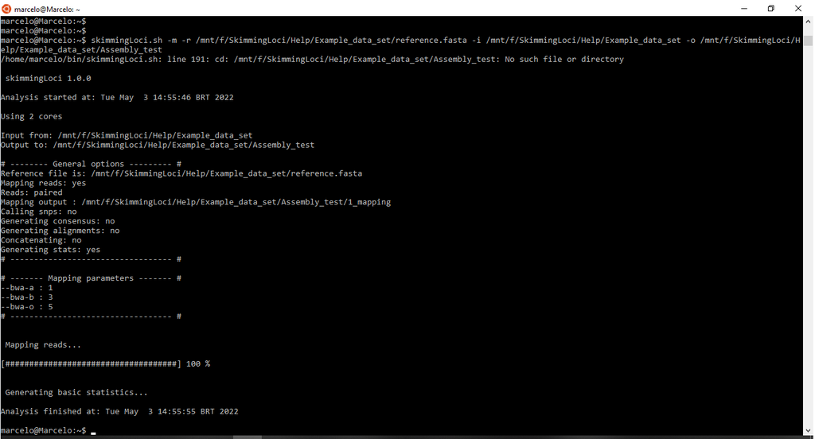

and a folder called ’1_mapping” within the specified with -o including these files:

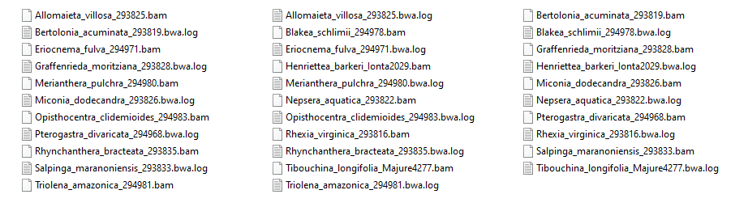

#### 2. SNP calling (-s)

This step uses the bam files (1_mapping/*.bam) and the reference file. It generates *.vcf files in a folder called ‘2_calling’. This folder is created by the pipeline within output directory (-o).

To run this step you need to specify: * reference file (-r) * the output directory (-o)

*Let’s run:*

```bash
skimmingLoci.sh -s -r /mnt/f/SkimmingLoci/Help/Example_data_set/reference.fasta -o /mnt/f/SkimmingLoci/Help/Example_data_set/Assembly_test
```

If everything went well, you should see something like this in the terminal:

[figure not shown]

and a folder called ’2_calling” within the specified with -o including these files:

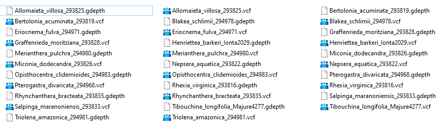

If you did not disable the stats option (with –no-stats) a file called “stats.samples.depth.txt” was created in the output directory. The file looks like this:

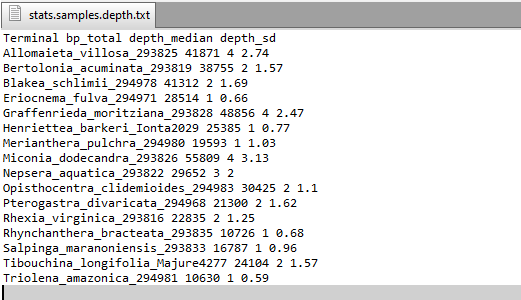

and a plot showing the depth distribution across all libraries, like this:

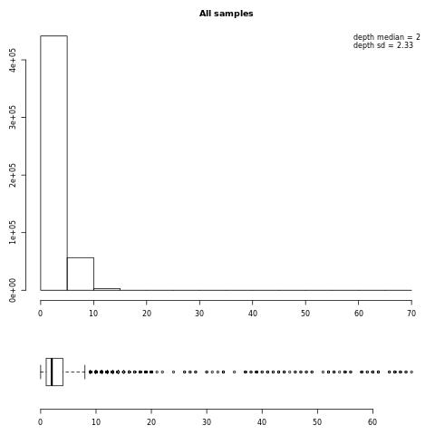

Additionally, plots of depth per library were created within the folder “2_calling”. The plot looks like this:

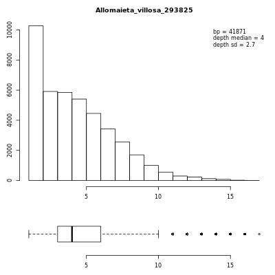

- You can check mean depth across your libraries to choose an optimal value for this parameter (–min-depth)

#### 3. Consensus (-c)

This step uses the vcf files (2_calling/*.vcf) and the reference file. It generates consensus sequences for each locus in the reference set for each assembly in *.fastq and *.fas (fasta) format in a folder called ‘3_consensus’. This folder is created by the pipeline within the output directory (-o). The *.fas files created in this step include all consensus sequences in fasta format arranged by library (the next step takes each locus from those files and generates fasta files by loci). It also generates *.lengths files, which include the number of assembled bases by loci, which will be used in the next step to include (or not) sequences in the final alignments.

To run this step you need to specify:

* reference file (-r) * the output directory (-o)

Other parameters you can change in this step are:

- mininum depth to keep a base call in the consensus sequence (–min-depth, default 3)
- maximum depth to keep a base call in the consensus sequence (–max-depth, default 100)
- minimum quality score to keep a base call in the consensus sequence (–min-Q, default 10)

*Let’s run:*

Despite the required options (-r and -o), let’s change the minimum depth parameter to 4 (default is 3) and the maximum depth parameter to 20 (default is 100). These flags will specify what is the minimum/maximum depth of a base call to be included in the consensus sequence (very important parameters). If the depth is outside of this range, the base call will be translated as missing data in the consensus sequence (“n”).

```bash
skimmingLoci.sh -c --min-depth 4 --max-depth 20 -r /mnt/f/SkimmingLoci/Help/Example_data_set/reference.fasta -o /mnt/f/SkimmingLoci/Help/Example_data_set/Assembly_test
```

If everything went well, you should see something like this in the terminal:

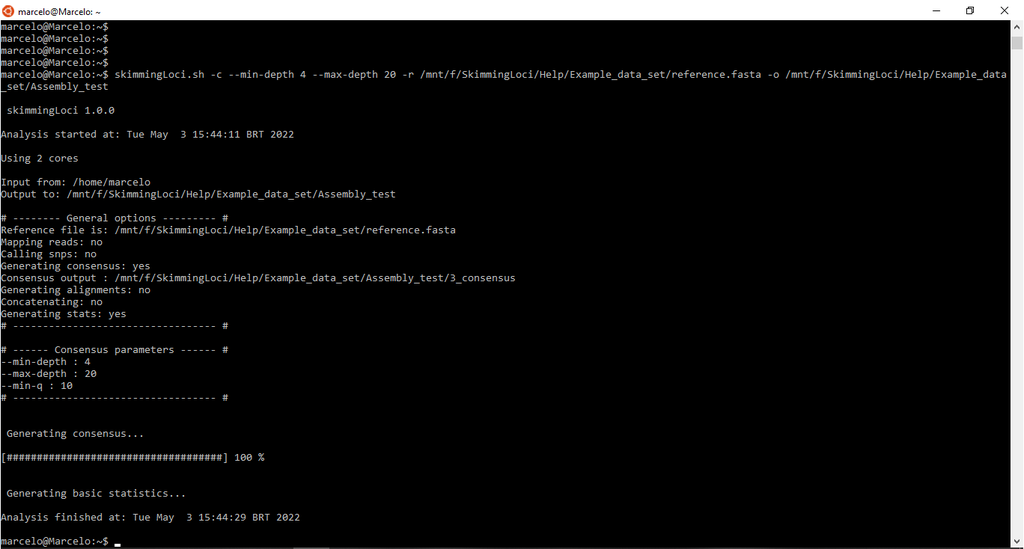

and a folder called ’3_consensus” within the specified with -o including these files:

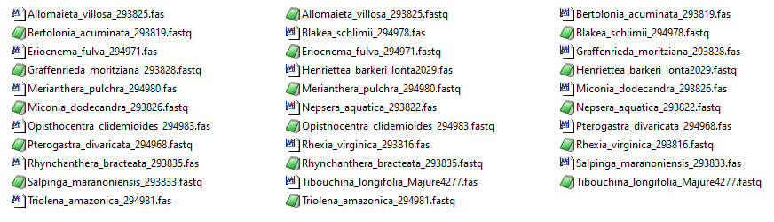

#### 4. Aligning (-a)

This step uses the .fas files (3_consensus/*.fas). It rearranges the sequences by loci (instead of by library as in 3_consensus), generating alignments for each locus. It generates two folders containing two sets of alignments: pre-filtering (4_aligns_all), which includes all sequences from the consensus, and a second folder including post-filtered (see parameters below) called “5_aligns_final”. Filtering alignments can be performed afterwards, so if you are planning to perform further filtering, it would be a good idea to keep these parameters relaxed here.

To run this step you need to specify: * reference file (-r) * the output directory (-o)

Parameters you can change in this step that will be used for filtering are:

- mininum coverage to keep a sequence in the final loci alignment (–min-cov)
- minimum number of sequences to keep an entire alignment in the final data set (–min-seq-num)
- trimm the alignment edges unting a mininum number of sequences (with no missing data) is found (–trim, default is don’t trim)

*Let’s run:*

Despite the required options (-r and -o), let’s change the minimum coverage to keep a sequence in the final alignment to 0.2 (default is 0.1, which will keep sequences with at least 10% of the reference) and the minimum number of sequences to not exclude the alighment to 5 (default is 4). Also, let’s enable the trimming option with the flag “–trim”, to remove base pairs in the alignment edges with less than 5 sequences without missing data (default is to leave the alignment edges untouched).

```bash
skimmingLoci.sh -a --min-cov 0.2 --min-seq-num 5 --trim 5 -r /mnt/f/SkimmingLoci/Help/Example_data_set/reference.fasta -o /mnt/f/SkimmingLoci/Help/Example_data_set/Assembly_test
```

If everything went well, you should see something like this in the terminal:

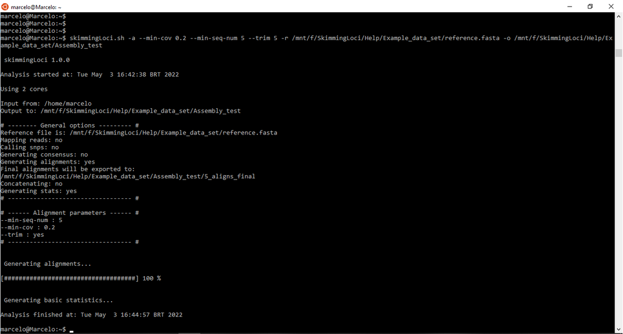

and this step will create two folders ‘4_aligns_all” (including pre-filtering alignments), and ’5_aligns_final’ (including post-filtering alignments, filtered using the –min.cov, –min.seq.num, and –trim options).

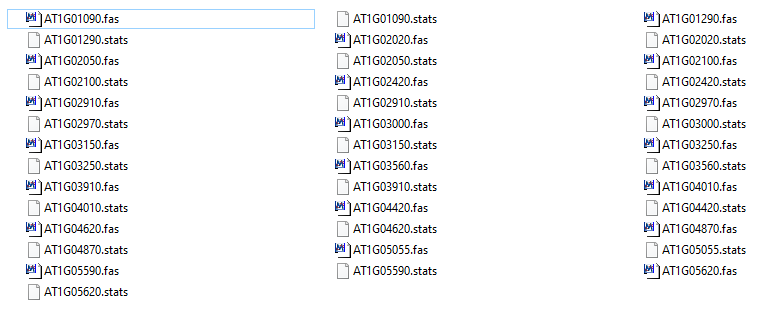

* The files *.stats include the number of base pairs of each library (and its coverage - % of the reference)

and the folder with the final filtered individual loci alignments:

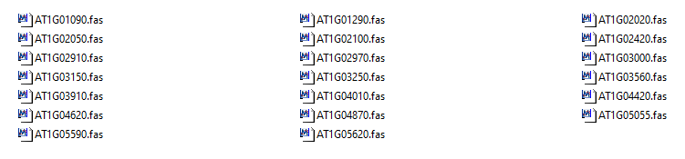

If you did not disable the stats option (with –no-stats) a file called “stats.loci.nseq.txt” was created in the output directory. In this file you’ll find the number of sequences per loci (pre-filtering). The file looks like this:

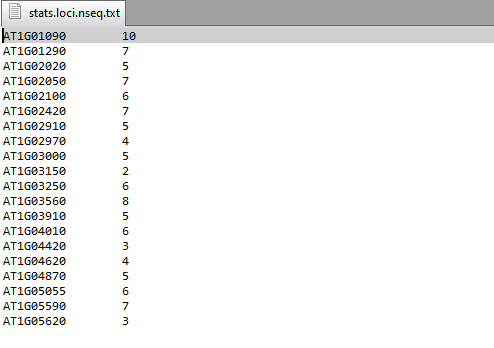

#### Concatenate (-N)

This step uses post-filtered alignments (5_aligns_final/*.fas). It generates 3 files in a folder called ‘6_concatenated’. This folder is created by the pipeline within output directory (-o).

To run this step you need to specify: * the output directory (-o)

No other parameter for this step.

*Let’s run:*

```bash
skimmingLoci.sh -N -r /mnt/f/SkimmingLoci/Help/Example_data_set/reference.fasta -o /mnt/f/SkimmingLoci/Help/Example_data_set/Assembly_test
```

If everything went well, you should see something like this in the terminal:

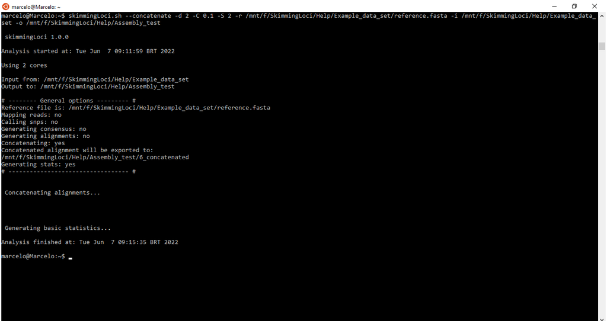

Within the folder ’6_concatenated” you will find the concatenated alignment in phylip format, and the other two are “maps” indicating the position of each locus in the concatenated alignment (one in RAxML format and the other in plain csv).

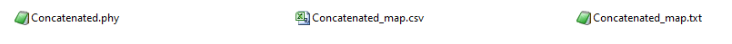

If you did not disable the stats option (with –no-stats) three files were created within the output directory: “stats.loci.final.txt”, “stats.samples.loci.txt”, and “stats.samples.loci.pdf”. The first two files are plain txt tables including basic statistics of loci (number of base pairs, PIS, etc…) and about libraries (number of loci recovered, total base pairs, etc…). The pdf file includes plots of number of loci and median coverage per library. The files should look like this:

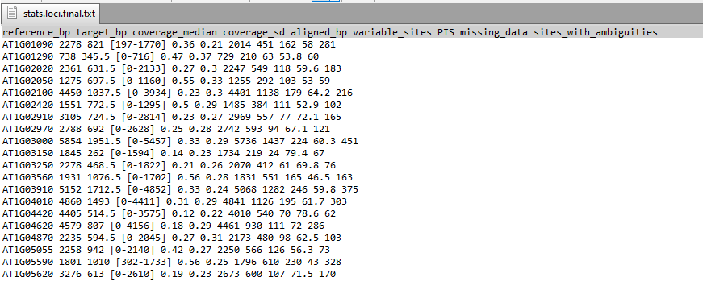

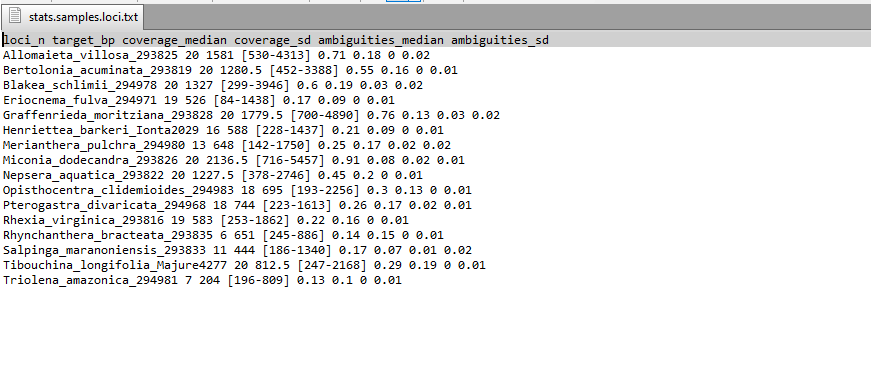

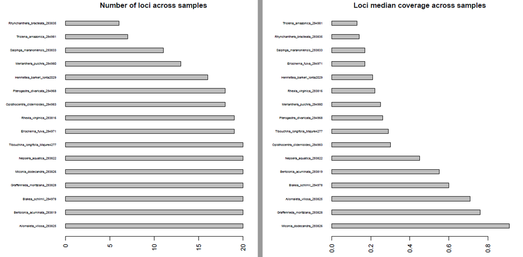

### At once

I guess it is a good idea to run step by step on a reduced data set just to make sure everything is running smoothly and also to figure what would be the best settings of key parameters (–min-cov, –min-depth, etc…). Additionally, running assemblies with different key paramters (–min-depth and –min-cov) could be done without running the previous steps. For instance, to run the pipeline with a different –min-cov value, you could start the pipeline from the -a step. But after you figure all of that, it is easier to run the entire pipeline with a single command. To run all the steps previously reported in this tutorial with a single command you could type:

```bash
skimmingLoci.sh -m -s -c -a -N --min-depth 4 --max-depth 20 --min-cov 0.2 --min-seq-num 5 --trim 5 -r /mnt/f/SkimmingLoci/Help/Example_data_set/reference.fasta -o /mnt/f/SkimmingLoci/Help/Example_data_set/Assembly_test
```

## Filtering loci (in R)

Further loci filtering can be performed in several ways. Here, we are going to use the companion R package skimmingLociR and functions from the package ape to filter the alignments. Additionally, we are going to use the basic stats generated in the pipeline to flag outlier loci and remove them.

### Packages

Let’s load the required packages (install them if you dont have).

```r
library(ape)
library(skimmingLociR)
library(outliers)
```

### Working dirs

First, let’s set up the directories we’ll be importing/exporting files. You’ll need to change these addresses.

```r
### Our main working directory
wd = "F:/SkimmingLoci/Help/Tutorial"

### Assembly directory (same use as -o in the pipeline)
assembly.dir = "F:/SkimmingLoci/Help/Assembly_test"

### New alignments (filtered) directory. Let's create it within the original assembly folder
new.align.dir = paste(assembly.dir, "/7_concatenated_filtered", sep="")
dir.create(new.align.dir)
```

### Input

Now, let’s import the basic statistics files generated in the assembly steps.

```r
setwd(assembly.dir)

read.table("stats.loci.final.txt", row.names=1, sep="\t") -> loci.s
read.table("stats.samples.loci.txt", row.names=1, sep="\t") -> samples.s

setwd(wd)

# Let's take a look a them:

head(loci.s)
```

```
##           reference_bp       target_bp coverage_median coverage_sd aligned_bp
## AT1G01090         2278  821 [197-1770]            0.36        0.21       2014
## AT1G01290          738   345.5 [0-716]            0.47        0.37        729
## AT1G02020         2361  631.5 [0-2133]            0.27        0.30       2247
## AT1G02050         1275  697.5 [0-1160]            0.55        0.33       1255
## AT1G02100         4450 1037.5 [0-3934]            0.23        0.30       4401
## AT1G02420         1551  772.5 [0-1295]            0.50        0.29       1485
##           variable_sites PIS missing_data sites_with_ambiguities
## AT1G01090            451 162         58.0                    281
## AT1G01290            210  63         53.8                     60
## AT1G02020            549 118         59.6                    183
## AT1G02050            292 103         53.0                     59
## AT1G02100           1138 179         64.2                    216
## AT1G02420            384 111         52.9                    102
```

```r
head(samples.s)
```

```
##                                loci_n         target_bp coverage_median
## Allomaieta_villosa_293825          20   1581 [530-4313]            0.71
## Bertolonia_acuminata_293819        20 1280.5 [452-3388]            0.55
## Blakea_schlimii_294978             20   1327 [299-3946]            0.60
## Eriocnema_fulva_294971             19     526 [84-1438]            0.17
## Graffenrieda_moritziana_293828     20 1779.5 [700-4890]            0.76
## Henriettea_barkeri_Ionta2029       16    588 [228-1437]            0.21
##                                coverage_sd ambiguities_median ambiguities_sd
## Allomaieta_villosa_293825             0.18               0.00           0.02
## Bertolonia_acuminata_293819           0.16               0.00           0.01
## Blakea_schlimii_294978                0.19               0.03           0.02
## Eriocnema_fulva_294971                0.09               0.00           0.01
## Graffenrieda_moritziana_293828        0.13               0.03           0.02
## Henriettea_barkeri_Ionta2029          0.09               0.00           0.01
```

Now, let’s import the final alignments generated in the pipeline.

```r
setwd(paste(assembly.dir, "/5_aligns_final",sep=""))

list.files(pattern=".fas") -> files
sub(".fas", "", files) -> labels

sapply(files, read.dna, "fasta", simplify=F) -> aligns
names(aligns) <- labels

setwd(wd)
```

### Outlier loci

As mentioned before, there are several ways that we could try to remove potentially problematic loci (from a phylogenetic perspective). We could get rid of loci that are too short, have too many gaps, too many ambiguities (paralogs?), too much missing data, and so on. Here we are going to flag outlier loci that are too short, have too many ambiguities and too much missing data. We are going to create a table saying whether or not we should remove a marker based on these parameters, then later we’ll remove them and generate new alignments.

First, let’s create a vector with loci names to store the info to whether or not remove them.

```r
loci.f <- vector(length=length(labels))
names(loci.f) <- labels
loci.f[] <- "keep"

loci.f
```

```
## AT1G01090 AT1G01290 AT1G02020 AT1G02050 AT1G02100 AT1G02420 AT1G02910 AT1G02970
##    "keep"    "keep"    "keep"    "keep"    "keep"    "keep"    "keep"    "keep"
## AT1G03000 AT1G03150 AT1G03250 AT1G03560 AT1G03910 AT1G04010 AT1G04420 AT1G04620
##    "keep"    "keep"    "keep"    "keep"    "keep"    "keep"    "keep"    "keep"
## AT1G04870 AT1G05055 AT1G05590 AT1G05620
##    "keep"    "keep"    "keep"    "keep"
```

Now, let’s start flagging them. We could set arbitraty values to flag the loci. Let’s say, we could remove loci with less than 500 bp, or with more than 50% missing data, and so on. But in this example we’ll use the package “outliers” to find outlier loci regarding the parameters we chose.

```r
################################
### By length

outlier(loci.s$aligned_bp, opposite = T) -> out.length
out.length
```

```
## [1] 729
```

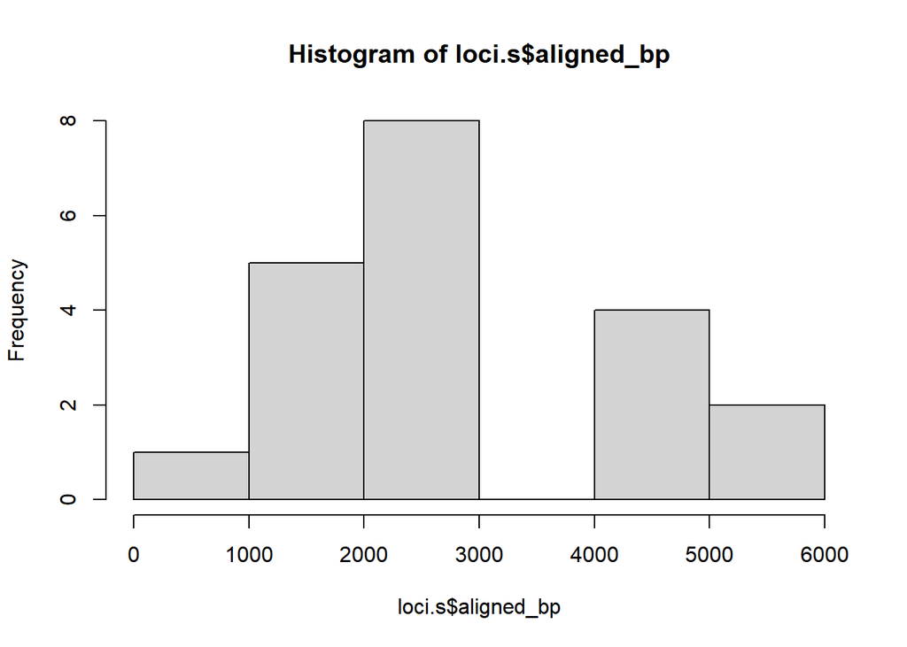

```r
# l.thresh = 1000 (to set an arbitrary value)
l.thresh = out.length

hist(loci.s$aligned_bp)
```

```r
loci.f[which(loci.s$aligned_bp <= l.thresh)] <- "remove"


################################
### By missing data

outlier(loci.s$missing_data, opposite = T) -> out.miss
out.miss
```

```
## [1] 79.4
```

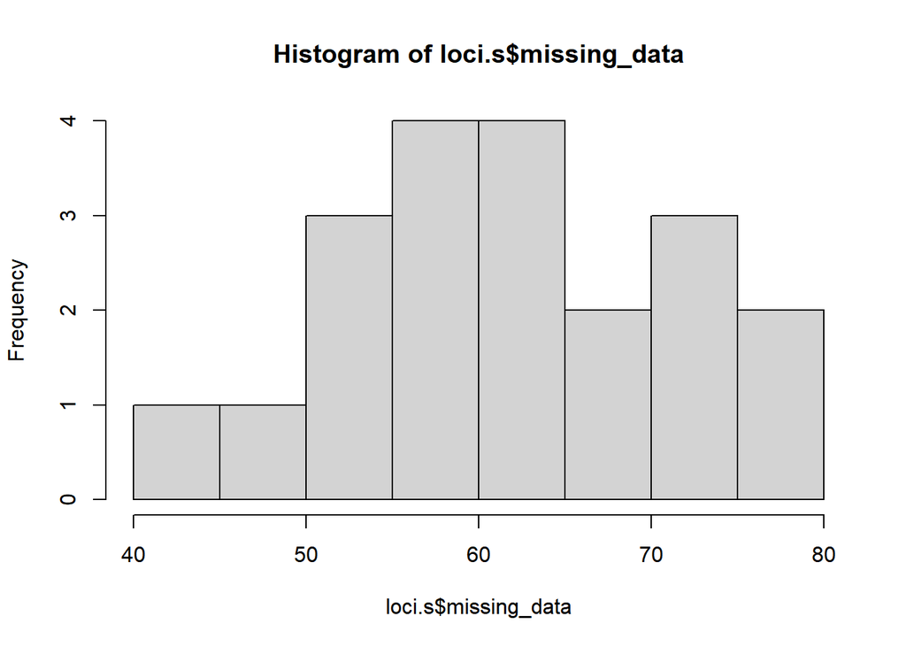

```r
m.thresh = out.miss

hist(loci.s$missing_data)
```

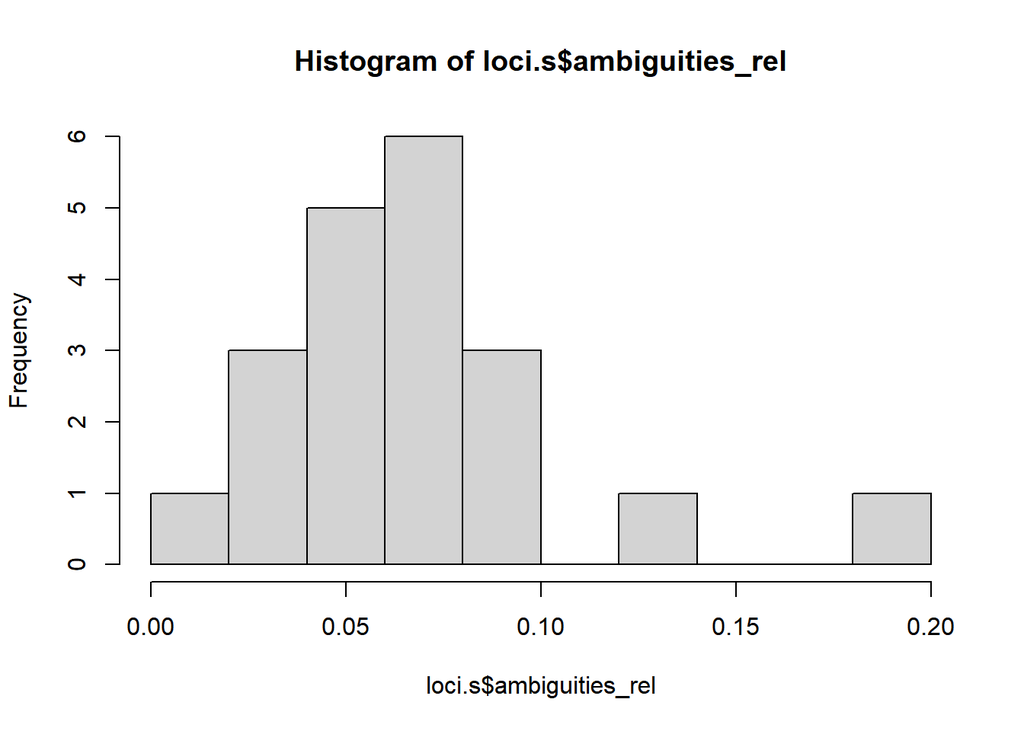

```r
loci.f[which(loci.s$missing_data >= m.thresh)] <- "remove"


################################
### with too many ambiguities

loci.s$sites_with_ambiguities / loci.s$aligned_bp -> loci.s$ambiguities_rel

outlier(loci.s$ambiguities_rel) -> out.a

a.thresh = out.a

hist(loci.s$ambiguities_rel)
```

```r
loci.f[which(loci.s$ambiguities_rel >= a.thresh)] <- "remove"
```

This is what we got. So, three loci will be removed from the filtered alignment.

```r
data.frame(loci.f)
```

```
##           loci.f
## AT1G01090   keep
## AT1G01290 remove
## AT1G02020   keep
## AT1G02050   keep
## AT1G02100   keep
## AT1G02420   keep
## AT1G02910   keep
## AT1G02970   keep
## AT1G03000   keep
## AT1G03150 remove
## AT1G03250   keep
## AT1G03560   keep
## AT1G03910   keep
## AT1G04010   keep
## AT1G04420   keep
## AT1G04620   keep
## AT1G04870   keep
## AT1G05055   keep
## AT1G05590 remove
## AT1G05620   keep
```

### Outlier libraries

Despite individual loci that might be problematic, entire libraries might also be a problem. Usually becasue they have too few assembled data. In this example, we’ll get rid of libraries that have too few loci, and very small coverage across loci. We’ll use the same procedure as before, let’s create a vector to keep the info and remove them later.

```r
samples.f <- vector(length=nrow(samples.s))
names(samples.f) <- rownames(samples.s)
samples.f[] <- "keep"

################################
### By number of loci

outlier(samples.s$loci_n, opposite = F) -> out.loci
out.loci
```

```
## [1] 6
```

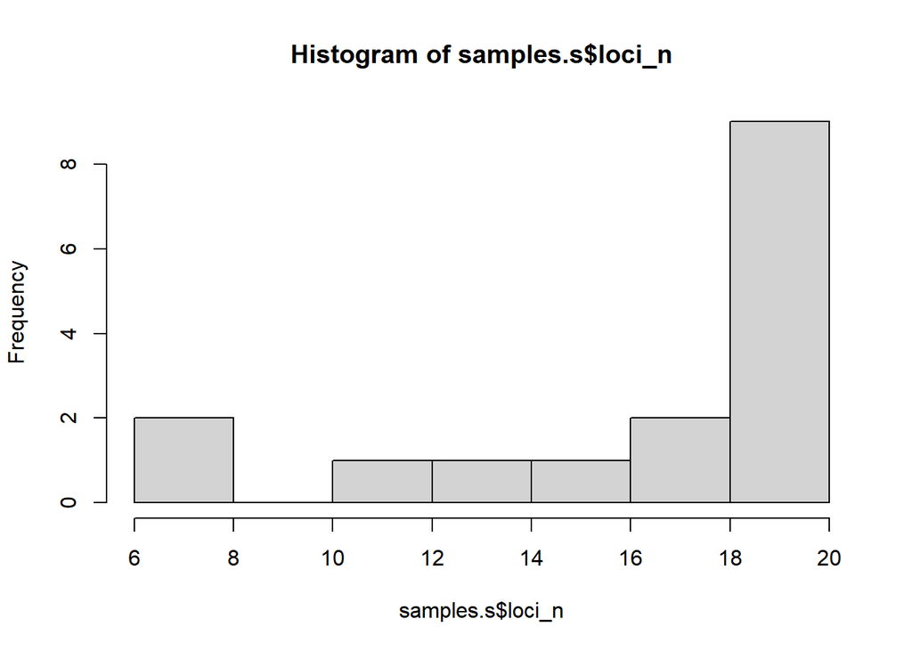

```r
# n.thresh = 10
n.thresh = out.loci

hist(samples.s$loci_n)
```

```r
samples.f[which(samples.s$loci_n <= n.thresh)] <- "remove"

################################
### By median coverage

outlier(samples.s$coverage_median, opposite = T) -> out.cov
out.cov
```

```
## [1] 0.13
```

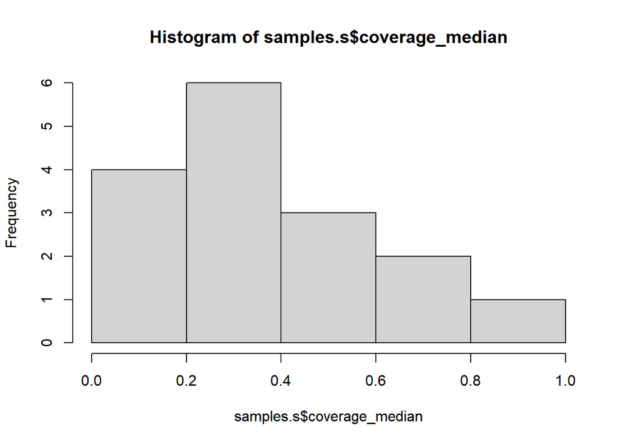

```r
# n.thresh = 10
c.thresh = out.cov

hist(samples.s$coverage_median)
```

```r
samples.f[which(samples.s$coverage_median <= c.thresh)] <- "remove"

################################

data.frame(samples.f)
```

```
##                                   samples.f
## Allomaieta_villosa_293825              keep
## Bertolonia_acuminata_293819            keep
## Blakea_schlimii_294978                 keep
## Eriocnema_fulva_294971                 keep
## Graffenrieda_moritziana_293828         keep
## Henriettea_barkeri_Ionta2029           keep
## Merianthera_pulchra_294980             keep
## Miconia_dodecandra_293826              keep
## Nepsera_aquatica_293822                keep
## Opisthocentra_clidemioides_294983      keep
## Pterogastra_divaricata_294968          keep
## Rhexia_virginica_293816                keep
## Rhynchanthera_bracteata_293835       remove
## Salpinga_maranoniensis_293833          keep
## Tibouchina_longifolia_Majure4277       keep
## Triolena_amazonica_294981            remove
```

### New alignments

Now we are going to remove the loci and libraries flagged in the previous steps. We’ll also trim the alignment edges (this could be done in the assembly steps, but we’ll do it now).

```r
### Remove loci

aligns[which(loci.f == "keep")] -> aligns.f

length(aligns.f) / length(aligns) ## percent of aligns kept
```

```
## [1] 0.85
```

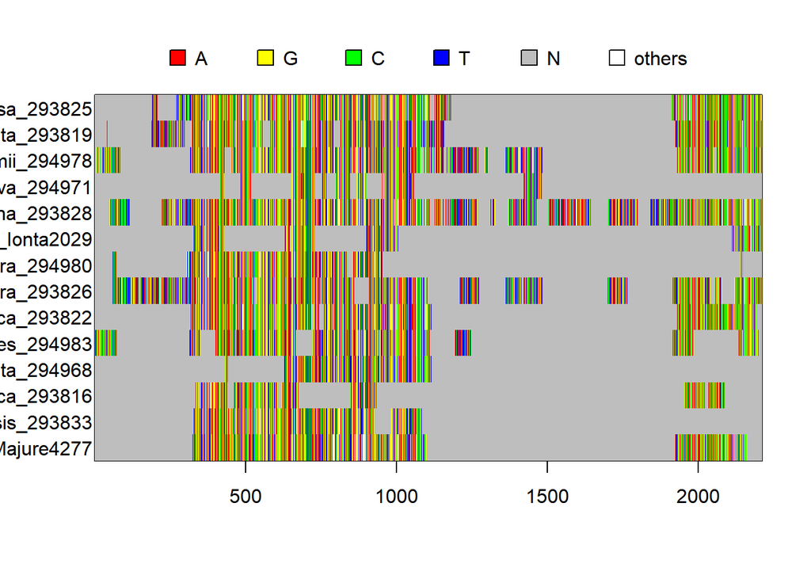

```r
### Remove libraries

names(which(samples.f == "keep")) -> keep.s
lapply(aligns.f, FUN=function(x)(x[which(is.na(match(rownames(x), keep.s))==F),])) -> aligns.f

### Trim (optional)
### This is an example of how one alignment looked before trimming

image(aligns.f[[1]])
```

```r
lapply(aligns.f, trimAligns, min.missing=0.5) -> aligns.f
```

```
## 332 sites were trimmed109 sites were trimmed60 sites were trimmed99 sites were trimmed288 sites were trimmed773 sites were trimmed971 sites were trimmed624 sites were trimmed188 sites were trimmed186 sites were trimmed253 sites were trimmed45 sites were trimmed121 sites were trimmed577 sites were…
```

```r
### Let's get rid of putative empty cells across the entire alignment

lapply(aligns.f, trimAligns, min.missing = 1, edges.only = F) -> aligns.f
```

```
## 196 sites were trimmed26 sites were trimmedNo trimming was necessary46 sites were trimmedNo trimming was necessary83 sites were trimmed5 sites were trimmed106 sites were trimmed120 sites were trimmedNo trimming was necessary67 sites were trimmed15 sites were trimmed211 sites were trimmed55 sites …
```

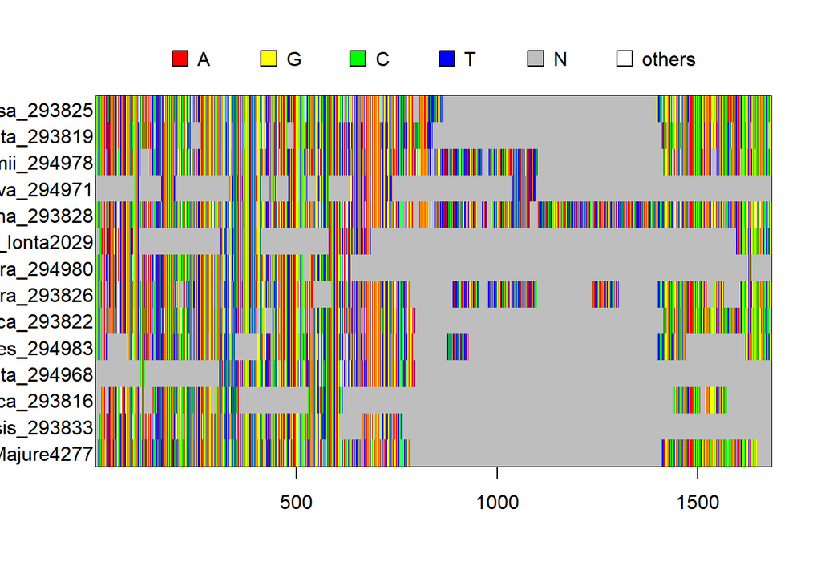

```r
### and after trimming

image(aligns.f[[1]])
```

### New stats

We can also generate new stats (since we removed libraries, the number of variable sites, PIS, might change).

```r
lapply(aligns.f, alignStats, include.amb=F) -> aligns.stats
do.call(rbind, aligns.stats) -> stats.n

### Export

setwd(assembly.dir)

write.table(stats.n, "loci.stats.filtered.txt", sep="\t", quote=F, na="")

setwd(wd)
```

### Export

Finally, we can concatenate and export the new alignment (with its map).

```r
### Concatenate

fastConc(aligns.f, fill.with.gaps = T, map = T) -> conc

### Export

setwd(new.align.dir)

writeRAxML(conc$align, file="concatenated.phy", map=conc$map)
```

So, check the folder “new.align.dir” (whatever address you put it), you should find a concatenated filtered alignment in phylip format there. Have a great inference!